# R Tutorial Homework 3

Valeria Montalvo Rivera

2026-Oct-02, 01:02 PM

Beginning of tutorial:

```r
# Checking if I have necessary packages and loading in the data:
library(ggplot2)
data("trees")
#?trees
head(trees)
```

```
##   Girth Height Volume
## 1   8.3     70   10.3
## 2   8.6     65   10.3
## 3   8.8     63   10.2
## 4  10.5     72   16.4
## 5  10.7     81   18.8
## 6  10.8     83   19.7
```

Q1. Create a histogram showing the distribution of Girth. Q1. Cree un histograma que muestre la distribución de Girth.

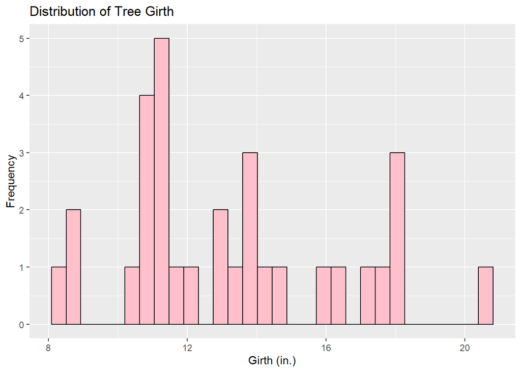

```r
# Lo que ncesitamos son tres cosas minimo: x, y, y que quiero hacer: el geom function
# Histogram solo necesita un x axis

plot_Girth <- ggplot(data=trees,
       aes(x= Girth)) +
  geom_histogram (fill="pink", color="black") +
  labs(title = "Distribution of Tree Girth",
       x = "Girth (in.)",
       y = "Frequency")

plot_Girth
```

Q2. Create a histogram showing the distribution of Volume. Q2. Cree un histograma que muestre la distribución de Volume.

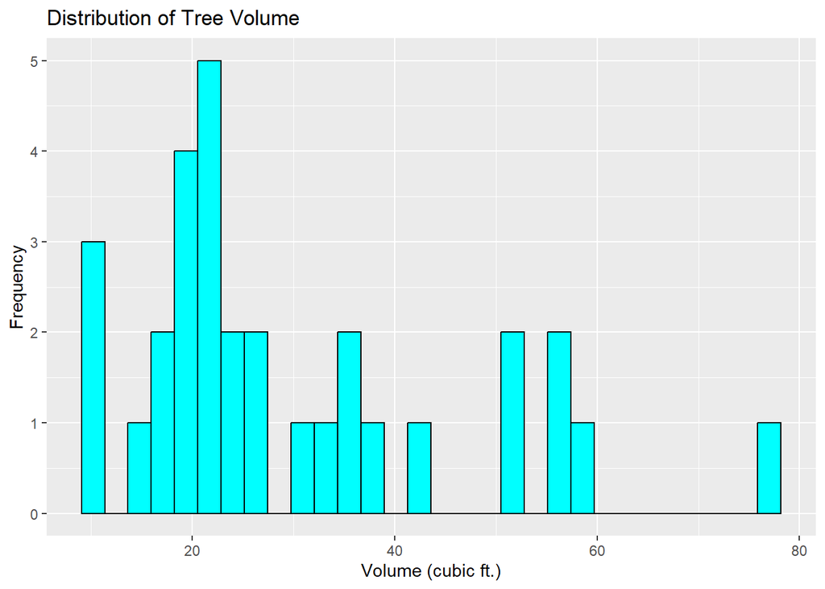

```r
plot_Volume <- ggplot(data=trees,
       aes(x= Volume)) +
  geom_histogram (fill="cyan", color="black") +
  labs(title = "Distribution of Tree Volume",
       x = "Volume (cubic ft.)",
       y = "Frequency")

plot_Volume
```

Q3. Create a scatterplot showing the relationship between Girth and Volume. Q3. Cree un gráfico de dispersión que muestre la relación entre Girth y Volume.

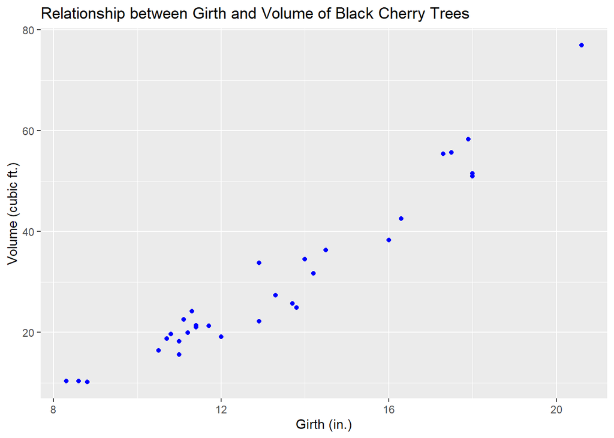

```r
plot_trees <- ggplot(data=trees,
       aes(x=Girth, y=Volume)) +
  geom_point(color= "blue") +
  labs(title="Relationship between Girth and Volume of Black Cherry Trees",
       x="Girth (in.)",
       y="Volume (cubic ft.)") +
  theme(legend.position = 'none')
plot_trees
```

Q4. Use the Shapiro–Wilk test to assess whether Volume is normally distributed. Report the p-value and state whether the data are normally distributed. Q4. Utilice la prueba de Shapiro–Wilk para evaluar si Volume tiene una distribución normal. Reporte el valor de p e indique si los datos tienen una distribución normal.

Answer: After the Shapiro-Wilk test was performed to test if Volume is normally distributed, the p-value obtained was 0.003579 (p < 0.05), which inidicates that there are significant differences between our data and a normal distribution. Therefore, Volume does not follow a normal distribution.

```r
# Shapiro-Wilk normality test for Volume
shapiro.test(trees$Volume)
```

```
##
##  Shapiro-Wilk normality test
##
## data:  trees$Volume
## W = 0.88757, p-value = 0.003579
```

Q5. Repeat the Shapiro–Wilk test for Girth. Report the p-value and state whether Girth is normally distributed. Q5. Repita la prueba de Shapiro–Wilk para Girth. Reporte el valor de p e indique si los datos tienen una distribución normal.

Answer: After the Shapiro-Wilk test was performed to test if Girth is normally distributed, the p-value obtained was 0.08893 (p > 0.05), which inidicates that there aren’t significant differences between our data and a normal distribution. Therefore, there is not enough evidence to say that Girth deviates from a normal distribution.

```r
# Shapiro-Wilk normality test for Girth
shapiro.test(trees$Girth)
```

```
##
##  Shapiro-Wilk normality test
##
## data:  trees$Girth
## W = 0.94117, p-value = 0.08893
```